# Assignment 6

In this assignment, you'll analyze a collection of data sets from the [San Francisco Open Data Portal](http://data.sfgov.org/) and [Zillow](https://www.zillow.com/). The data sets have been stored in the SQLite database `sf_data.sqlite`, which you can [download here](http://anson.ucdavis.edu/~nulle/sf_data.sqlite). The database contains the following tables:

| Table | Description |
| --- | --- |
| `crime` | Crime reports dating back to 2010. |
| `mobile_food_locations` | List of all locations where mobile food vendors sell. |
| `mobile_food_permits` | List of all mobile food vendor permits. More details [here](https://data.sfgov.org/api/views/rqzj-sfat/files/8g2f5RV4PEk0_b24iJEtgEet9gnh_eA27GlqoOjjK4k?download=true&filename=DPW_DataDictionary_Mobil… |
| `mobile_food_schedule` | Schedules for mobile food vendors. |
| `noise` | Noise complaints dating back to August 2015. |
| `parking` | List of all parking lots. |
| `parks` | List of all parks. |
| `schools` | List of all schools. |
| `zillow` | Zillow rent and housing statistics dating back to 1996. More details [here](https://www.zillow.com/research/data/). |

The `mobile_food_` tables are explicitly connected through the `locationid` and `permit` columns. The other tables are not connected, but you may be able to connect them using dates, latitude/longitude, or postal codes.

Shapefiles for US postal codes are available [here](https://www.census.gov/geo/maps-data/data/cbf/cbf_zcta.html). These may be useful for converting latitude/longitude to postal codes.

Shapefiles for San Francisco Neighborhoods are available [here](https://data.sfgov.org/Geographic-Locations-and-Boundaries/SF-Find-Neighborhoods/pty2-tcw4).

**Exercise 1.1.** Which mobile food vendor(s) sells at the most locations?

```python
import sqlite3 as sql
```

```python
db = sql.connect("sf_data.sqlite")
```

```python
cursor = db.execute("SELECT * FROM sqlite_master")
```

```python
cursor.fetchall()
```

```
[(u'table',
  u'crime',
  u'crime',
  2,
  u'CREATE TABLE "crime" (\n"IncidntNum" INTEGER,\n  "Category" TEXT,\n  "Descript" TEXT,\n  "DayOfWeek" TEXT,\n  "Datetime" TIMESTAMP,\n  "PdDistrict" TEXT,\n  "Resolution" TEXT,\n  "Address" TEXT,\n  "Lon" REAL,\n  "Lat" REAL\n)'),
 (u'table',
  u'noise',
  u'noise',
  35775,
  u'CREATE TABLE "noise" (\n"CaseID" INTEGER,\n  "Type" TEXT,\n  "Address" TEXT,\n  "Neighborhood" TEXT,\n  "Datetime" TIMESTAMP,\n  "Lat" REAL,\n  "Lon" REAL\n)'),
 (u'table',
  u'parking',
  u'parking',
  35921,
  u'CREATE TABLE "parking" (\n"Owner" TEXT,\n  "Address" TEXT,\n  "PrimeType" TEXT,\n  "SecondType" TEXT,\n  "GarOrLot" TEXT,\n  "RegCap" INTEGER,\n  "ValetCap" INTEGER,\n  "MCCap" INTEGER,\n  "LandType" TEXT,\n  "Lat" REAL,\n  "Lon" REAL\n)'),
 (u'table',
  u'schools',
  u'schools',
  35944,
  u'CREATE TABLE "schools" (\n"Name" TEXT,\n  "Entity" TEXT,\n  "LowerGrade" INTEGER,\n  "UpperGrade" INTEGER,\n  "GradeRange" TEXT,\n  "Category" TEXT,\n  "LowerAge" INTEGER,\n  "UpperAge" INTEGER,\n  "GeneralType" TEXT,\n  "Address" TEXT,\n  "Lat" REAL,\n  "Lon" REAL\n)'),
 (u'table',
  u'parks',
  u'parks',
  35961,
  u'CREATE TABLE "parks" (\n"Name" TEXT,\n  "Type" TEXT,\n  "Acreage" REAL,\n  "ParkID" INTEGER,\n  "Lat" REAL,\n  "Lon" REAL\n)'),
 (u'table',
  u'zillow',
  u'zillow',
  35967,
  u'CREATE TABLE "zillow" (\n"RegionName" INTEGER,\n  "Date" TIMESTAMP,\n  "ZriPerSqft_AllHomes" REAL,\n  "MedianSoldPricePerSqft_AllHomes" REAL,\n  "PriceToRentRatio_AllHomes" REAL,\n  "Turnover_AllHomes" REAL\n)'),
 (u'table',
  u'mobile_food_permits',
  u'mobile_food_permits',
  36050,
  u'CREATE TABLE "mobile_food_permits" (\n"permit" TEXT,\n  "Status" TEXT,\n  "Applicant" TEXT,\n  "FacilityType" TEXT,\n  "FoodItems" TEXT,\n  "PriorPermit" INTEGER,\n  "Approved" TIMESTAMP,\n  "Expiration" TIMESTAMP\n)'),
 (u'table',
  u'mobile_food_locations',
  u'mobile_food_locations',
  36060,
  u'CREATE TABLE "mobile_food_locations" (\n"locationid" INTEGER,\n  "LocationDescription" TEXT,\n  "Address" TEXT,\n  "Latitude" REAL,\n  "Longitude" REAL\n)'),
 (u'table',
  u'mobile_food_schedule',
  u'mobile_food_schedule',
  36079,
  u'CREATE TABLE "mobile_food_schedule" (\n"locationid" INTEGER,\n  "permit" TEXT,\n  "DayOfWeek" TEXT,\n  "EndHour" INTEGER,\n  "StartHour" INTEGER\n)')]
```

```python
import pandas as pd
```

```python
pd.read_sql("SELECT * FROM sqlite_master", db)
```

|  | type | name | tbl_name | rootpage | sql |
| --- | --- | --- | --- | --- | --- |
| 0 | table | crime | crime | 2 | CREATE TABLE "crime" (\n"IncidntNum" INTEGER,\... |
| 1 | table | noise | noise | 35775 | CREATE TABLE "noise" (\n"CaseID" INTEGER,\n "... |
| 2 | table | parking | parking | 35921 | CREATE TABLE "parking" (\n"Owner" TEXT,\n "Ad... |
| 3 | table | schools | schools | 35944 | CREATE TABLE "schools" (\n"Name" TEXT,\n "Ent... |
| 4 | table | parks | parks | 35961 | CREATE TABLE "parks" (\n"Name" TEXT,\n "Type"... |
| 5 | table | zillow | zillow | 35967 | CREATE TABLE "zillow" (\n"RegionName" INTEGER,... |
| 6 | table | mobile_food_permits | mobile_food_permits | 36050 | CREATE TABLE "mobile_food_permits" (\n"permit"... |
| 7 | table | mobile_food_locations | mobile_food_locations | 36060 | CREATE TABLE "mobile_food_locations" (\n"locat... |
| 8 | table | mobile_food_schedule | mobile_food_schedule | 36079 | CREATE TABLE "mobile_food_schedule" (\n"locati... |

```python
mob_loc = pd.read_sql("SELECT * FROM mobile_food_locations", db)
mob_per = pd.read_sql("SELECT * FROM mobile_food_permits", db)
mob_sch = pd.read_sql("SELECT * FROM mobile_food_schedule", db)
```

```python
mob_loc.head()
```

|  | locationid | LocationDescription | Address | Latitude | Longitude |
| --- | --- | --- | --- | --- | --- |
| 0 | 762182 | TOWNSEND ST: 05TH ST to 06TH ST (400 - 499) | 444 TOWNSEND ST | 37.774871 | -122.398532 |
| 1 | 437211 | MISSOURI ST: 20TH ST to SIERRA ST (500 - 630) | 555 MISSOURI ST | 37.759304 | -122.395902 |
| 2 | 765880 | 17TH ST: SAN BRUNO AVE to UTAH ST (2200 - 2299) | 2222 17TH ST | 37.765216 | -122.406007 |
| 3 | 765690 | CESAR CHAVEZ ST: EVANS AVE to KANSAS ST (2100 ... | 2323 CESAR CHAVEZ ST | 37.748801 | -122.400552 |
| 4 | 751253 | FOLSOM ST: 14TH ST to 15TH ST (1800 - 1899) | 1800 FOLSOM ST | 37.767852 | -122.416105 |

```python
mob_per.head()
```

|  | permit | Status | Applicant | FacilityType | FoodItems | PriorPermit | Approved | Expiration |
| --- | --- | --- | --- | --- | --- | --- | --- | --- |
| 0 | 16MFF-0027 | APPROVED | F & C Catering | Truck | Cold Truck: Hot/Cold Sandwiches: Water: Soda: ... | 1 | 2016-03-09 12:00:00 | 2017-03-15 12:00:00 |
| 1 | 13MFF-0102 | EXPIRED | Natan's Catering | Truck | Burgers: melts: hot dogs: burritos:sandwiches:... | 1 | 2013-04-12 12:00:00 | 2014-03-15 12:00:00 |
| 2 | 16MFF-0069 | APPROVED | Munch A Bunch | Truck | Cold Truck: packaged sandwiches: pitas: breakf... | 1 | 2016-03-15 12:00:00 | 2017-03-15 12:00:00 |
| 3 | 16MFF-0051 | APPROVED | Park's Catering | Truck | Cold Truck: Hamburger: cheeseburgers: hot dogs... | 1 | 2016-03-15 12:00:00 | 2017-03-15 12:00:00 |
| 4 | 16MFF-0010 | REQUESTED | Pipo's Grill | Truck | Tacos: Burritos: Hot Dogs: and Hamburgers | 0 | None | None |

```python
mob_sch.head()
```

|  | locationid | permit | DayOfWeek | EndHour | StartHour |
| --- | --- | --- | --- | --- | --- |
| 0 | 305727 | 11MFF-0040 | Mo | 15 | 10 |
| 1 | 305727 | 11MFF-0040 | Tu | 15 | 10 |
| 2 | 305727 | 11MFF-0040 | We | 15 | 10 |
| 3 | 305727 | 11MFF-0040 | Th | 15 | 10 |
| 4 | 305727 | 11MFF-0040 | Fr | 15 | 10 |

```python
print len(mob_loc.index), len(mob_sch.index), len(mob_per.index)
```

```
754 3592 195
```

```python
newdf = pd.read_sql("SELECT * FROM mobile_food_locations INNER JOIN mobile_food_schedule ON mobile_food_locations.locationID = mobile_food_schedule.locationID INNER JOIN mobile_food_permits ON mobile_food_permits.permit = mobile_food_schedule.permit", db)
```

```python
newdf.head()
```

|  | locationid | LocationDescription | Address | Latitude | Longitude | locationid | permit | DayOfWeek | EndHour | StartHour | permit | Status | Applicant | FacilityType | FoodItems | PriorPermit | Approved | Expiration |
| --- | --- | --- | --- | --- | --- | --- | --- | --- | --- | --- | --- | --- | --- | --- | --- | --- | --- | --- |
| 0 | 762182 | TOWNSEND ST: 05TH ST to 06TH ST (400 - 499) | 444 TOWNSEND ST | 37.774871 | -122.398532 | 762182 | 16MFF-0027 | Fr | 11 | 10 | 16MFF-0027 | APPROVED | F & C Catering | Truck | Cold Truck: Hot/Cold Sandwiches: Water: Soda: ... | 1 | 2016-03-09 12:00:00 | 2017-03-15 12:00:00 |
| 1 | 762182 | TOWNSEND ST: 05TH ST to 06TH ST (400 - 499) | 444 TOWNSEND ST | 37.774871 | -122.398532 | 762182 | 16MFF-0027 | Mo | 11 | 10 | 16MFF-0027 | APPROVED | F & C Catering | Truck | Cold Truck: Hot/Cold Sandwiches: Water: Soda: ... | 1 | 2016-03-09 12:00:00 | 2017-03-15 12:00:00 |
| 2 | 762182 | TOWNSEND ST: 05TH ST to 06TH ST (400 - 499) | 444 TOWNSEND ST | 37.774871 | -122.398532 | 762182 | 16MFF-0027 | Th | 11 | 10 | 16MFF-0027 | APPROVED | F & C Catering | Truck | Cold Truck: Hot/Cold Sandwiches: Water: Soda: ... | 1 | 2016-03-09 12:00:00 | 2017-03-15 12:00:00 |
| 3 | 762182 | TOWNSEND ST: 05TH ST to 06TH ST (400 - 499) | 444 TOWNSEND ST | 37.774871 | -122.398532 | 762182 | 16MFF-0027 | Tu | 11 | 10 | 16MFF-0027 | APPROVED | F & C Catering | Truck | Cold Truck: Hot/Cold Sandwiches: Water: Soda: ... | 1 | 2016-03-09 12:00:00 | 2017-03-15 12:00:00 |
| 4 | 762182 | TOWNSEND ST: 05TH ST to 06TH ST (400 - 499) | 444 TOWNSEND ST | 37.774871 | -122.398532 | 762182 | 16MFF-0027 | We | 11 | 10 | 16MFF-0027 | APPROVED | F & C Catering | Truck | Cold Truck: Hot/Cold Sandwiches: Water: Soda: ... | 1 | 2016-03-09 12:00:00 | 2017-03-15 12:00:00 |

```python
# Gets most frequent vendor
newdf['Applicant'].value_counts().idxmax
```

```
<bound method Series.idxmax of May Catering                                                               340
Natan's Catering                                                           221
Anas Goodies Catering                                                      212
Liang Bai Ping                                                             182
Mang Hang Catering                                                         165
Park's Catering                                                            134
Steve's Mobile Deli                                                        125
John's Catering #5                                                         120
Singh Brothers Ice Cream                                                   105
Sun Rise Catering                                                          100
Two G's Catering                                                            98
M M Catering                                                                96
Quan Catering                                                               95
D & T Catering                                                              85
Mini Mobile Food Catering                                                   85
Mike's Catering                                                             83
F & C Catering                                                              79
Bach Catering                                                               60
Munch A Bunch                                                               52
San Francisco Carts & Concessions, Inc. DBA Stanley's Steamers Hot Dogs     42
Kara's Cupcakes                                                             41
BH & MT LLC                                                                 40
Halal Cart, LLC                                                             37
Linda's Catering                                                            35
The New York Frankfurter Co. of CA, Inc. DBA: Annie's Hot Dogs              35
San Francisco Street Foods, Inc.                                            35
Tacos Rodriguez                                                             34
Golden Catering                                                             31
Bombay Blvd.                                                                28
Tacos El Primo                                                              23
                                                                          ...
Slider Shack, LLC.                                                           5
Smokin Warehouse Barbecue                                                    5
Tacos El Flaco                                                               5
Eli's Hot Dogs                                                               5
Mr. Nice, LLC                                                                5
Bonito Poke                                                                  4
Halal Cart of San Francisco                                                  4
Hiyaaa                                                                       4
Peruchi Food Truck,LLC                                                       3
Loma Linda                                                                   3
A Taste of Chicago                                                           3
Let's Be Frank                                                               3
El Calamar Perubian Food Truck                                               3
Alfaro's Truck                                                               3
Ruru Soul                                                                    3
Breaking Bread Inc.                                                          3
The Huge Hotdog Concession                                                   3
Rita's Catering                                                              3
Golden Gate Halal Food                                                       3
Missing Link SF                                                              3
Kiss Point                                                                   3
Viet Duong Co., Ltd.                                                         3
Geary Cocina                                                                 3
Raspados El Yocateco                                                         3
The Brooklyn Pig Inc.                                                        3
Mob Dog                                                                      3
Mario's Colombian and Mexican Food                                           3
Fruteria Serrano                                                             3
Buenafe                                                                      3
Munch India                                                                  2
Name: Applicant, dtype: int64>
```

May Catering sells at the most locations.

**Exercise 1.2.** Ask and use the database to analyze 5 questions about San Francisco. For each question, write at least 150 words and support your answer with plots. Make a map for at least 2 of the 5 questions.

You should try to come up with some questions on your own, but these are examples of reasonable questions:

- Which parts of the city are the most and least expensive?
- Which parts of the city are the most dangerous (and at what times)?
- Are noise complaints and mobile food vendors related?
- What are the best times and places to find food trucks?
- Is there a relationship between housing prices and any of the other tables?

Please make sure to clearly state each of your questions in your submission.

```python
from mpl_toolkits.basemap import Basemap
%matplotlib inline
import matplotlib.pyplot as plt
import numpy as np
```

Which types of schools does San Francisco have most of and least of?

```python
schools = pd.read_sql("SELECT * FROM schools", db)
```

```python
schools.head()
```

|  | Name | Entity | LowerGrade | UpperGrade | GradeRange | Category | LowerAge | UpperAge | GeneralType | Address | Lat | Lon |
| --- | --- | --- | --- | --- | --- | --- | --- | --- | --- | --- | --- | --- |
| 0 | Alamo Elementary School | SFUSD | 0 | 5 | K-5 | USD Grades K-5 | 5 | 10 | PS | 250 23RD AVE, San Francisco, CA 94121 | 37.783005 | -122.482300 |
| 1 | Alvarado Elementary School | SFUSD | 0 | 5 | K-5 | USD Grades K-5 | 5 | 10 | PS | 625 DOUGLASS ST, San Francisco, CA 94114 | 37.753681 | -122.438194 |
| 2 | Aptos Middle School | SFUSD | 6 | 8 | 6-8 | USD Grades 6-8 | 11 | 13 | PS | 105 APTOS AVE, San Francisco, CA 94127 | 37.729672 | -122.465782 |
| 3 | Argonne Early Education School | SFUSD | -2 | 0 | PK-TK | USD PreK/TK | 3 | 5 | PS | 750 16TH AVE, San Francisco, CA 94118 | 37.773968 | -122.474060 |
| 4 | Argonne Elementary School | SFUSD | 0 | 5 | K-5 | USD Grades K-5 | 5 | 10 | PS | 680 18TH AVE, San Francisco, CA 94121 | 37.775307 | -122.476311 |

```python
schools['GradeRange'].value_counts().idxmax
```

```
<bound method Series.idxmax of PK       165
K-8       65
K-5       51
9-12      36
PK-5      26
6-8       16
PK-K      13
K-12      11
13-14     10
PK-8       8
6-12       6
PK-4       6
8-12       4
TK-8       3
INF        3
3-8        2
TK-2       2
K-6        2
7-12       2
PK-TK      2
5-12       1
4-8        1
1-6        1
K-1        1
K-4        1
K-2        1
PK-12      1
1-4        1
PK-6       1
5-8        1
2-12       1
1-8        1
Name: GradeRange, dtype: int64>
```

Which areas in San Francisco are the best areas to find parking?

```python
parking = pd.read_sql("SELECT * FROM parking", db)
```

```python
parking.head()
```

|  | Owner | Address | PrimeType | SecondType | GarOrLot | RegCap | ValetCap | MCCap | LandType | Lat | Lon |
| --- | --- | --- | --- | --- | --- | --- | --- | --- | --- | --- | --- |
| 0 | Private | 2110 Market St | PPA |  | L | 13 | 0 | 0 | restaurant | 37.767378 | -122.429344 |
| 1 | SFMTA | 993 Potrero | PPA |  | L | 34 | 0 | 0 |  | 37.757272 | -122.406320 |
| 2 | Port of SF | 601 Terry A Francois Blvd | PPA |  | L | 72 | 0 | 0 |  | 37.770135 | -122.385801 |
| 3 | Private | 11 SOUTH VAN NESS | PHO | CPO | G | 130 | 0 | 0 |  | 37.774150 | -122.418402 |
| 4 | Private | 101 CALIFORNIA ST | PPA |  | G | 250 | 0 | 0 |  | 37.793243 | -122.397495 |

```python
lotspace = parking.loc[parking['RegCap'] > 500]
```

```python
plt.figure(figsize=(15,10))
displaymap = Basemap(llcrnrlon=-122.5,llcrnrlat=37.7,urcrnrlon=-122.4,urcrnrlat=37.8, resolution = "h", projection ="merc")
```

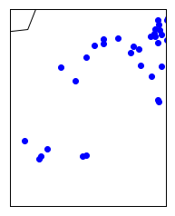

```python
# Convert longitudes and latitudes to list of floats
longitude = lotspace[['Lon']].values.tolist()
for i in range(0, len(longitude)):
    longitude[i] = float(longitude[i][0])
latitude = lotspace[['Lat']].values.tolist()
for i in range(0, len(latitude)):
    latitude[i] = float(latitude[i][0])
displaymap.drawmapboundary()
displaymap.drawcountries()
displaymap.drawcoastlines()
lons,lats = displaymap(longitude, latitude)
displaymap.plot(lons, lats, 'bo', color = "blue")
```

I defined the best parking areas to be spaces where the RegCap which is the maximum spaces allowed for parking to be greater than 500. From the map of San Francisco, it looks like most of those parking spaces are in the northeastern area of San Francisco.

Which areas in San Francisco have the most noise? Which type of noise causes the most noise and which areas in San Francisco have the most type of that noise?

```python
noise = pd.read_sql("SELECT * FROM noise", db)
```

```python
noise.head()
```

|  | CaseID | Type | Address | Neighborhood | Datetime | Lat | Lon |
| --- | --- | --- | --- | --- | --- | --- | --- |
| 0 | 5130305 | other_excessive_noise | Not associated with a specific address | None | 2015-09-25 00:29:33 | NaN | NaN |
| 1 | 6446138 | amplified_sound_electronics | Intersection of CLINTON PARK and GUERRERO ST | Mission Dolores | 2016-10-21 13:20:18 | 37.769148 | -122.424475 |
| 2 | 5929789 | other_excessive_noise | 1301 48TH AVE, SAN FRANCISCO, CA, 94122 | Outer Sunset | 2016-06-01 11:38:59 | 37.762047 | -122.508365 |
| 3 | 5659943 | other_excessive_noise | 736 LEAVENWORTH ST, SAN FRANCISCO, CA, 94109 | Lower Nob Hill | 2016-03-13 01:18:27 | 37.787983 | -122.414943 |
| 4 | 5930704 | other_excessive_noise | 1360 43RD AVE, SAN FRANCISCO, CA, 94122 | Outer Sunset | 2016-06-01 13:58:43 | 37.761385 | -122.502232 |

```python
# deletes all N/A locations
noiseknown = noise.loc[np.isnan(noise['Lat']) == False]
```

```python
plt.figure(figsize=(15,10))
displaymap = Basemap(llcrnrlon=-122.5,llcrnrlat=37.7,urcrnrlon=-122.4,urcrnrlat=37.8, resolution = "h", projection ="merc")
```

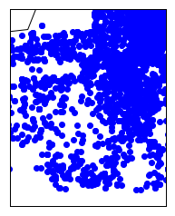

```python
# Convert longitudes and latitudes to list of floats
longitude = noiseknown[['Lon']].values.tolist()
for i in range(0, len(longitude)):
    longitude[i] = float(longitude[i][0])
latitude = noiseknown[['Lat']].values.tolist()
for i in range(0, len(latitude)):
    latitude[i] = float(latitude[i][0])
displaymap.drawmapboundary()
displaymap.drawcountries()
displaymap.drawcoastlines()
lons,lats = displaymap(longitude, latitude)
displaymap.plot(lons, lats, 'bo', color = "blue")
```

From the map, it looks like most parts of San Francisco have noise but the eastern part seems to have more noise than the western part of San Francisco.

```python
noise['Type'].value_counts().idxmax
```

```
<bound method Series.idxmax of other_excessive_noise            1222
construction_private_property     795
amplified_sound_electronics       499
construction_public               386
mechanical_equipment              367
entertainment                     331
garbage_recycling_collection      261
traffic                           206
other_reallocate                  200
major_event_venue                 143
delivery_service_business          92
vehicle_car_alarm                  72
sirens                             41
tour_bus                           31
home_improvement_maintenance       30
delivery_service_vehicle           28
construction_emergency             27
vehicle_repair                     14
protest_speech_bullhorns           12
delivery_service_construction       9
emergency_equipment                 9
public_speech                       9
mobile_food_facility                7
hospital                            4
Name: Type, dtype: int64>
```

```python
noisecon = noiseknown[noiseknown['Type'] == 'construction_private_property']
```

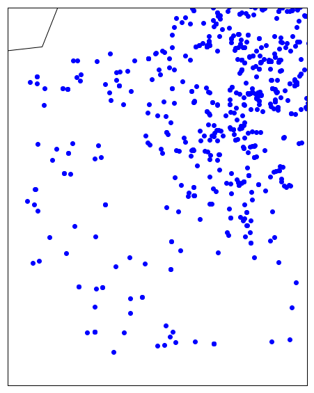

```python
plt.figure(figsize=(15,10))
displaymap = Basemap(llcrnrlon=-122.5,llcrnrlat=37.7,urcrnrlon=-122.4,urcrnrlat=37.8, resolution = "h", projection ="merc")
# Convert longitudes and latitudes to list of floats
longitude = noisecon[['Lon']].values.tolist()
for i in range(0, len(longitude)):
    longitude[i] = float(longitude[i][0])
latitude = noisecon[['Lat']].values.tolist()
for i in range(0, len(latitude)):
    latitude[i] = float(latitude[i][0])
displaymap.drawmapboundary()
displaymap.drawcountries()
displaymap.drawcoastlines()
lons,lats = displaymap(longitude, latitude)
displaymap.plot(lons, lats, 'bo', color = "blue")
```

Aside from other types of excessive noise which isn't in a specific category, the factor that causes the most noise is construction on private property. The points for construction noise is spread throughout the map of San Francisco but most of it is gathered around in the north eastern area of San Francisco.

Which parts of the city are the least expensive and which are the most expensive?

```python
zillow = pd.read_sql("SELECT * FROM zillow", db)
```

```python
zillow.head()
```

|  | RegionName | Date | ZriPerSqft_AllHomes | MedianSoldPricePerSqft_AllHomes | PriceToRentRatio_AllHomes | Turnover_AllHomes |
| --- | --- | --- | --- | --- | --- | --- |
| 0 | 94109 | 2010-11-01 00:00:00 | 3.156 | 675.1913 | 19.14 | 6.0771 |
| 1 | 94110 | 2010-11-01 00:00:00 | 2.566 | 599.6785 | 18.10 | 5.4490 |
| 2 | 94122 | 2010-11-01 00:00:00 | 2.168 | 495.4432 | 17.99 | 2.4198 |
| 3 | 94080 | 2010-11-01 00:00:00 | 1.666 | 369.5538 | 18.31 | 3.8757 |
| 4 | 94112 | 2010-11-01 00:00:00 | 2.322 | 422.4538 | 14.44 | 3.1288 |

```python
priceknown = zillow.loc[np.isnan(zillow['MedianSoldPricePerSqft_AllHomes']) == False]
```

```python
maxprice = priceknown['MedianSoldPricePerSqft_AllHomes'].max()
expensive = priceknown.loc[priceknown['MedianSoldPricePerSqft_AllHomes'] == maxprice]
minprice = priceknown['MedianSoldPricePerSqft_AllHomes'].min()
cheap = priceknown.loc[priceknown['MedianSoldPricePerSqft_AllHomes'] == minprice]
print expensive.iloc[0]['RegionName'], cheap.iloc[0]['RegionName']
```

```
94104 94124
```

I based my answer on median sold price per square feet for all homes in one region. The most expensive houses are in the 94104 region and the cheapest houses are in the 94124 region.

Which types of violent crimes occur the most in San Francisco and which parts do they occur in the most?

```python
crime = pd.read_sql("SELECT * FROM crime", db)
```

```python
crime.head()
```

|  | IncidntNum | Category | Descript | DayOfWeek | Datetime | PdDistrict | Resolution | Address | Lon | Lat |
| --- | --- | --- | --- | --- | --- | --- | --- | --- | --- | --- |
| 0 | 150060275 | NON-CRIMINAL | LOST PROPERTY | Monday | 2015-01-19 14:00:00 | MISSION | NONE | 18TH ST / VALENCIA ST | -122.421582 | 37.761701 |
| 1 | 150098210 | ROBBERY | ROBBERY, BODILY FORCE | Sunday | 2015-02-01 15:45:00 | TENDERLOIN | NONE | 300 Block of LEAVENWORTH ST | -122.414406 | 37.784191 |
| 2 | 150098210 | ASSAULT | AGGRAVATED ASSAULT WITH BODILY FORCE | Sunday | 2015-02-01 15:45:00 | TENDERLOIN | NONE | 300 Block of LEAVENWORTH ST | -122.414406 | 37.784191 |
| 3 | 150098210 | SECONDARY CODES | DOMESTIC VIOLENCE | Sunday | 2015-02-01 15:45:00 | TENDERLOIN | NONE | 300 Block of LEAVENWORTH ST | -122.414406 | 37.784191 |
| 4 | 150098226 | VANDALISM | MALICIOUS MISCHIEF, VANDALISM OF VEHICLES | Tuesday | 2015-01-27 19:00:00 | NORTHERN | NONE | LOMBARD ST / LAGUNA ST | -122.431119 | 37.800469 |

```python
crime['Category'].value_counts().idxmax
```

```
<bound method Series.idxmax of LARCENY/THEFT                  243144
OTHER OFFENSES                 141431
NON-CRIMINAL                   125702
ASSAULT                         90029
VANDALISM                       54467
WARRANTS                        46061
VEHICLE THEFT                   43685
DRUG/NARCOTIC                   43674
SUSPICIOUS OCC                  40894
BURGLARY                        40851
MISSING PERSON                  32261
ROBBERY                         25706
FRAUD                           19848
SECONDARY CODES                 13499
WEAPON LAWS                     10767
TRESPASS                         9188
STOLEN PROPERTY                  6658
FORGERY/COUNTERFEITING           5971
SEX OFFENSES, FORCIBLE           5803
PROSTITUTION                     5281
DRUNKENNESS                      4658
RECOVERED VEHICLE                4510
DISORDERLY CONDUCT               4358
DRIVING UNDER THE INFLUENCE      3017
KIDNAPPING                       2726
ARSON                            1771
RUNAWAY                          1677
LIQUOR LAWS                      1547
EMBEZZLEMENT                     1166
LOITERING                         606
SUICIDE                           544
FAMILY OFFENSES                   517
BRIBERY                           445
EXTORTION                         303
BAD CHECKS                        281
SEX OFFENSES, NON FORCIBLE        191
GAMBLING                          126
PORNOGRAPHY/OBSCENE MAT            25
TREA                               13
Name: Category, dtype: int64>
```

```python
assault = crime[crime['Category'] == 'ASSAULT']
```

```python
assault.head()
```

|  | IncidntNum | Category | Descript | DayOfWeek | Datetime | PdDistrict | Resolution | Address | Lon | Lat |
| --- | --- | --- | --- | --- | --- | --- | --- | --- | --- | --- |
| 2 | 150098210 | ASSAULT | AGGRAVATED ASSAULT WITH BODILY FORCE | Sunday | 2015-02-01 15:45:00 | TENDERLOIN | NONE | 300 Block of LEAVENWORTH ST | -122.414406 | 37.784191 |
| 22 | 150098414 | ASSAULT | AGGRAVATED ASSAULT WITH BODILY FORCE | Sunday | 2015-02-01 17:05:00 | CENTRAL | ARREST, BOOKED | PACIFIC AV / GRANT AV | -122.406832 | 37.796903 |
| 23 | 150098414 | ASSAULT | BATTERY WITH SERIOUS INJURIES | Sunday | 2015-02-01 17:05:00 | CENTRAL | ARREST, BOOKED | PACIFIC AV / GRANT AV | -122.406832 | 37.796903 |
| 25 | 150098420 | ASSAULT | AGGRAVATED ASSAULT WITH BODILY FORCE | Sunday | 2015-02-01 17:10:00 | TENDERLOIN | ARREST, BOOKED | 400 Block of ELLIS ST | -122.413609 | 37.784697 |
| 29 | 150098458 | ASSAULT | BATTERY OF A POLICE OFFICER | Sunday | 2015-02-01 16:56:00 | MISSION | ARREST, BOOKED | 2000 Block of MISSION ST | -122.419520 | 37.764229 |

```python
assault['PdDistrict'].value_counts().idxmax
```

```
<bound method Series.idxmax of SOUTHERN      15114
MISSION       13580
BAYVIEW       11631
INGLESIDE      9844
NORTHERN       9479
TENDERLOIN     8764
CENTRAL        8257
TARAVAL        6180
PARK           3745
RICHMOND       3435
Name: PdDistrict, dtype: int64>
```

I defined violent crimes as those that cause people bodily harm and found that assault is the most common of those crimes. The Southern, Mission and Bayview district have the most number of these types of crimes.

```python
db.close()
```